# Calculated phi-values from ND PRNs.

```python
import pandas as pd
import numpy as np
import os
import matplotlib.pyplot as plt
from scipy.stats import spearmanr, ttest_rel
from scipy.stats import ttest_ind_from_stats as tts
```

```python
Qs =[0.1, 0.2, 0.3, 0.4, 0.5, 0.6, 0.7, 0.8, 0.9, 1.0]
dirname = "Paci_ND3"
PIDs = ["1imq", "1lmb4", "1bf4", "2ptl", "2ci2", "1aps", "1fmk", "1bk2", "1shf", "1ten"]
```

```python
EDVs = ['a'] # EDVs = ['a', 'b', 's', 'l', 'v']
NDVs = ['c', 'x', 'r', 'a', 'y']
ndv_colors = ['tab:blue', 'tab:orange', 'tab:green', 'tab:red', 'tab:purple']
```

```python
# computed previously
c_peak_Qs = np.array([0.2, 0.3, 0.3, 0.3, 0.3, 0.3, 0.2, 0.2, 0.2, 0.3])
x_peak_Qs = np.array([0.2, 0.3, 0.3, 0.3, 0.3, 0.3, 0.2, 0.2, 0.2, 0.2])
r_peak_Qs = np.array([0.2, 0.2, 0.2, 0.2, 0.2, 0.2, 0.2, 0.1, 0.2, 0.2])
a_peak_Qs = np.array([0.2, 0.3, 0.3, 0.3, 0.3, 0.3, 0.2, 0.2, 0.2, 0.2])
y_peak_Qs = np.array([0.2, 0.1, 0.2, 0.2, 0.2, 0.2, 0.1, 0.1, 0.1, 0.1])

# cxray
peak_Qs = np.column_stack([c_peak_Qs, x_peak_Qs, r_peak_Qs, a_peak_Qs, y_peak_Qs])
peak_Qs
```

```
array([[0.2, 0.2, 0.2, 0.2, 0.2],
       [0.3, 0.3, 0.2, 0.3, 0.1],
       [0.3, 0.3, 0.2, 0.3, 0.2],
       [0.3, 0.3, 0.2, 0.3, 0.2],
       [0.3, 0.3, 0.2, 0.3, 0.2],
       [0.3, 0.3, 0.2, 0.3, 0.2],
       [0.2, 0.2, 0.2, 0.2, 0.1],
       [0.2, 0.2, 0.1, 0.2, 0.1],
       [0.2, 0.2, 0.2, 0.2, 0.1],
       [0.3, 0.2, 0.2, 0.2, 0.1]])
```

### Mean Absolute Difference/Errror between experimental $\phi$ values and calculated $\phi$ values.

```python
def mad_from_phi(ndv, edv):
    dirn = os.path.join(dirname, "edv_a") # ND data
    ofn = os.path.join(dirname, ndv + "_phi_mad.out")
    fout = open(ofn, "w"); fout.close() # truncates existing file
    fout = open(ofn, "a") # appends to file
    fout.write("pid Q mad_deg_avg mad_deg_avg2 mad_cent_avg mad_cent_avg2\n")
    for pid in PIDs:
        fn0 = os.path.join(dirname, pid + "_nodestats.out") # NS
        df0 = pd.read_table(fn0, sep="\s+") # nid exp_phi deg0 cent0
        N = len(df0)
        fn1 = os.path.join(dirn, pid + "_" + ndv + "_nodestats.out") # ND
        df1 = pd.read_table(fn1, sep="\s+") # Q nid deg_avg cent_avg
        for q in Qs:
            dq = df1.query("Q == @q")
            m = dq.deg_avg.max() # normalize then select phi residues
            dq = dq.assign(deg_avg_norm = dq.deg_avg.values/m)
            # prop. of native degree
            dq = dq.assign(deg_avg_norm2 = dq.deg_avg.values/df0.deg0.values)
            m = dq.cent_avg.max()
            dq = dq.assign(cent_avg_norm = dq.cent_avg.values/m)
            # fraction of all paths
            dq = dq.assign(cent_avg_norm2 = dq.cent_avg.values/(N*N-N))
            dq = dq.assign(exp_phi = df0.exp_phi.values)
            de = dq.query("exp_phi > -1")
            a = np.round(np.mean(np.abs(de.deg_avg_norm.values - de.exp_phi.values)), 3)
            b = np.round(np.mean(np.abs(de.cent_avg_norm.values - de.exp_phi.values)), 3)
            a2 = np.round(np.mean(np.abs(de.deg_avg_norm2.values - de.exp_phi.values)), 3)
            b2 = np.round(np.mean(np.abs(de.cent_avg_norm2.values - de.exp_phi.values)), 3)
            fout.write("{0} {1} {2} {3} {4} {5}\n".format(pid, q, a, a2, b, b2))
    fout.close()
    df = pd.read_table(ofn, sep=' ')
    # in general a2 > a
    # count = np.sum(df.mad_deg_avg.values > df.mad_deg_avg2.values) # 21, 22, 19, 21, 14
    # in general b2 > b
    # count = np.sum(df.mad_cent_avg.values > df.mad_cent_avg2.values) # 16, 16, 56, 20, 64
    # in general a2 > b2, desire to minimize mad, but cannot conclude to use b2 at this point!
    count = np.sum(df.mad_deg_avg2.values > df.mad_cent_avg2.values) # 80, 78, 88, 86, 89
    # print(ndv, edv, count, len(df))
    return count
```

```python
# this cell takes some time to run, only need to do this once to create ndv_phi_mad.out files
counts = [] # deg > cent mad across all Qs for each pid
for edv in EDVs:
    row = []
    for ndv in NDVs:
        count = mad_from_phi(ndv, edv)
        row.append(count)
    counts.append(row)

counts
```

```
[[80, 78, 88, 86, 89]]
```

```python
# formats counts and do summation
df = pd.DataFrame(counts).assign(EDV=EDVs).set_index("EDV")
df.columns = NDVs
s = df.sum(axis=0) # col sum
s.name = "sum"
df = df.append(s)
df = df.assign(sum = df.sum(axis=1)) # row sum
df
```

| EDV | c | x | r | a | y | sum |
| --- | --- | --- | --- | --- | --- | --- |
| a | 80 | 78 | 88 | 86 | 89 | 421 |
| sum | 80 | 78 | 88 | 86 | 89 | 421 |

- Max per cell in the table is 100: 10 pids with 10 Qs each = 100 trials per NDV,EDV pair. Smaller MAD is better.
- At least 78% of the time (over all $Q$s), calculating phi-values with (normalized) node degree produces larger MAD than doing so with (normalised) node centrality.
  - ND phi-values calculated with node centrality correspond better with experimental phi-values than ND phi-values calculated with node degree.
  - Count results suggest to calculate ND phi-values from node centrality. But cannot conclude this yet; results with minimum MAD is suggest otherwise!
- Another consideration beside MAD from exp. $\phi$: $Q$ where MAD is minimum is inside ND-TS region?
  - $\phi$ values are a property of TS structures.

```python
# load the ndv_phi_mad.out files
edv = 'a'
cxray_dfs = []
for ndv in NDVs:
    fn = os.path.join(dirname, ndv + "_phi_mad.out")
    df = pd.read_table(fn, sep=' ')
    cxray_dfs.append(df)
```

```python
import random
random.seed()
# mean_95CI with resampling/bootstrap
def bootstrap(vals):
    means = np.zeros(10000); stdevs = np.zeros(10000)
    for i in np.arange(10000):
        resample = random.choices(vals, k=10) # with replacement
        means[i], stdevs[i] = np.mean(resample), np.std(resample, ddof=1)
    a, z = np.percentile(means, 2.5), np.percentile(means, 97.5)
    moe = (z-a)/2.0
    return moe, a, z

# calc the 95%CI of the mean, with sample stdev, n >= 30
def mean_95CI(sample_mean, sample_stdev, sample_size):
    moe = (1.96 * sample_stdev)/np.sqrt(sample_size) # margin of error
    return moe, sample_mean - moe, sample_mean + moe

def summary_stats(vals):
    mu = np.mean(vals); snu = np.std(vals, ddof=1)
    gmoe, ga, gz = mean_95CI(mu, snu, 10) # Gaussian estimated
    bmoe, ba, bz = bootstrap(vals) # bootstrap
    return np.round([mu, snu, np.ptp(vals), gmoe, ga, gz, bmoe, ba, bz], 4)
```

```python
def plot_CIs(MADstats_df, minQstats_df):
    methods = MADstats_df.columns.values; n = len(methods)
    plt_colors = plt.get_cmap("tab20")
    gcolors = plt_colors(list(range(1, n*2, 2))) # odd
    bcolors = plt_colors(list(range(0, n*2, 2))) # even
    fig, axes = plt.subplots(2, 1, figsize=(6, 8), constrained_layout=True)
    ax = axes[0]
    mu = MADstats_df.loc['sample_avg'].values
    ga = MADstats_df.loc['95meanCI_gleft'].values
    gz = MADstats_df.loc['95meanCI_gright'].values
    ba = MADstats_df.loc['95meanCI_bleft'].values
    bz = MADstats_df.loc['95meanCI_bright'].values
    for i, p in enumerate(zip(ga, gz, ba, bz)):
        ax.plot([i, i], [p[0], p[1]], marker='o', color=gcolors[i])
        ax.plot([i+0.2, i+0.2], [p[2], p[3]], marker='o', color=bcolors[i], label=str(p[3]))
        ax.scatter(i+0.2, mu[i], marker='^')
    ax.legend(title="97.5 percentile", loc="upper left", bbox_to_anchor=(1.0, 1.0))
    ax.set_title("mean MAD from exp_phi", fontsize=14)
    ax.set_ylabel("95% confidence interval", fontsize=14)
    ax.set_xticks(list(range(0, n, 1))); ax.set_xticklabels(methods, fontsize=14)
    ax.grid()
    ax = axes[1]
    mu = minQstats_df.loc['sample_avg'].values
    ga = minQstats_df.loc['95meanCI_gleft'].values
    gz = minQstats_df.loc['95meanCI_gright'].values
    ba = minQstats_df.loc['95meanCI_bleft'].values
    bz = minQstats_df.loc['95meanCI_bright'].values
    for i, p in enumerate(zip(ga, gz, ba, bz)):
        ax.plot([i, i], [p[0], p[1]], marker='o', color=gcolors[i])
        ax.plot([i+0.2, i+0.2], [p[2], p[3]], marker='o', color=bcolors[i], label=str(p[3]))
        ax.scatter(i+0.2, mu[i], marker='^')
    ax.legend(title="97.5 percentile", loc="upper left", bbox_to_anchor=(1.0, 1.0))
    ax.set_title("mean minQ", fontsize=14)
    ax.set_ylabel("95% confidence interval", fontsize=14)
    ax.set_xticks(list(range(0, n, 1))); ax.set_xticklabels(methods, fontsize=14)
    ax.grid()
    return plt
```

### Node centrality

```
1imq [0.186 0.18  0.169 0.187 0.164] [0.2 0.2 0.2 0.2 0.2]
1lmb4 [0.29  0.237 0.303 0.377 0.304] [0.3 0.3 0.9 0.4 1. ]
1bf4 [0.221 0.23  0.212 0.232 0.214] [0.1 0.1 0.2 0.1 0.2]
2ptl [0.221 0.222 0.208 0.236 0.207] [0.1 0.1 0.2 0.1 0.2]
2ci2 [0.155 0.15  0.162 0.175 0.165] [0.1 0.1 0.2 0.1 0.2]
1aps [0.193 0.21  0.192 0.211 0.195] [0.1 0.1 0.2 0.1 0.2]
1fmk [0.26  0.257 0.29  0.276 0.295] [0.1 0.1 0.2 0.1 0.2]
1bk2 [0.177 0.175 0.166 0.203 0.154] [0.1 0.1 0.3 0.1 0.3]
1shf [0.283 0.267 0.293 0.304 0.305] [0.1 0.1 0.2 0.1 0.2]
1ten [0.174 0.187 0.149 0.151 0.146] [0.1 0.1 0.2 0.1 0.3]
```

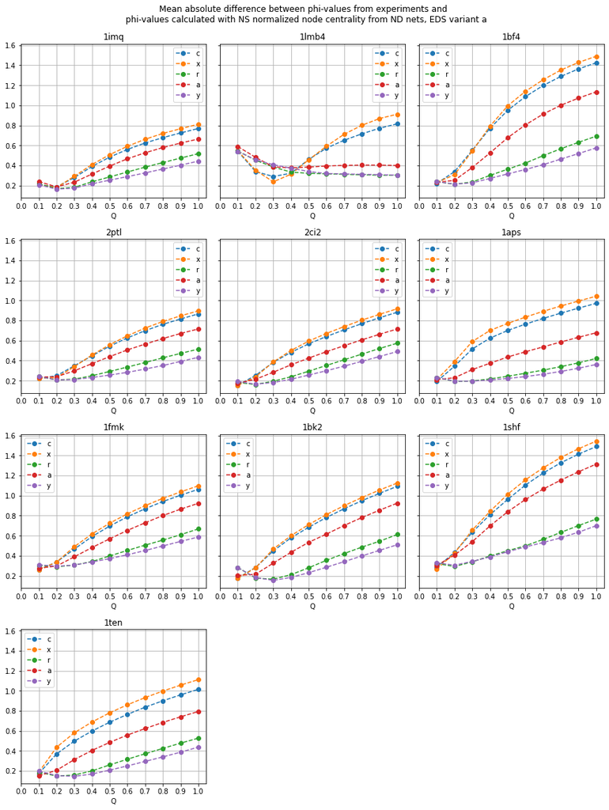

```python
# compare mads of ND variants
fig, axes = plt.subplots(4, 3, figsize=(12, 16), constrained_layout=True, sharey=True)
plt.suptitle("Mean absolute difference between phi-values from experiments and \n \
phi-values calculated with NS normalized node centrality from ND nets, EDS variant " + edv)
plt.delaxes(axes[3][1])
plt.delaxes(axes[3][2])

min_mads, min_Qs = [], []
for i, pid in enumerate(PIDs):
    r = i//3; c = i%3; ax = axes[r][c]
    res = []
    for i, ndv in enumerate(NDVs):
        dp = cxray_dfs[i].query("pid == @pid")
        # mad = dp.mad_cent_avg.values
        mad = dp.mad_cent_avg2.values
        ax.plot(Qs, mad, 'o--', label=ndv)
        res.append(mad)
    ax.set_title(pid)
    ax.set_xlabel('Q'); ax.set_xticks(np.arange(0, 1.1, 0.1))
    ax.legend(); ax.grid()
    min_mad = np.round(np.min(res, axis=1), 3) # row-wise per ND variant, over Qs for a pid
    min_q = (np.round(np.argmin(res, axis=1), 3) + 1)/10
    min_mads.append(min_mad)
    min_Qs.append(min_q)
    print(pid, min_mad, min_q)

# ofn = os.path.join(dirname, "ND_centphi_" + edv + ".png")
# print(ofn)
# plt.savefig(ofn)
```

```python
# can skip if file already created
cent_minmad_df = pd.DataFrame(min_mads)
cent_minmad_df.columns = NDVs
cent_minmad_df = cent_minmad_df.assign(pid=PIDs).set_index('pid')
ofn = os.path.join(dirname, "ND_centphi_minmad_" + edv + ".out")
cent_minmad_df.to_csv(ofn, sep=' ')

cent_MADstats_df = pd.DataFrame({ "MAD_stats": ["sample_avg", "sample_stdev", "range", \
                                  "gMOE", "95meanCI_gleft", "95meanCI_gright",
                                  "bMOE", "95meanCI_bleft", "95meanCI_bright",],
                "c": summary_stats(cent_minmad_df['c'].values),
                "x": summary_stats(cent_minmad_df['x'].values),
                "r": summary_stats(cent_minmad_df['r'].values),
                "a": summary_stats(cent_minmad_df['a'].values),
                "y": summary_stats(cent_minmad_df['y'].values) })
cent_MADstats_df = cent_MADstats_df.set_index("MAD_stats")

# ofn = os.path.join(dirname, "ND_cent_MADstats_" + edv + ".out")
# cent_MADstats_df.to_csv(ofn, sep=' ')
```

```python
# can skip if file already created
cent_minQ_df = pd.DataFrame(min_Qs)
cent_minQ_df.columns = NDVs
cent_minQ_df = cent_minQ_df.assign(pid=PIDs).set_index('pid')
ofn = os.path.join(dirname, "ND_centphi_minQ_" + edv + ".out")
cent_minQ_df.to_csv(ofn, sep=' ')

cent_minQstats_df = pd.DataFrame({ "minQ_stats": ["sample_avg", "sample_stdev", "range", \
                                "gMOE", "95meanCI_gleft", "95meanCI_gright",
                                "bMOE", "95meanCI_bleft", "95meanCI_bright"],
                "c": summary_stats(cent_minQ_df['c'].values),
                "x": summary_stats(cent_minQ_df['x'].values),
                "r": summary_stats(cent_minQ_df['r'].values),
                "a": summary_stats(cent_minQ_df['a'].values),
                "y": summary_stats(cent_minQ_df['y'].values)})
cent_minQstats_df = cent_minQstats_df.set_index("minQ_stats")

# ofn = os.path.join(dirname, "ND_cent_minQstats_" + edv + ".out")
# cent_minQstats_df.to_csv(ofn, sep=' ')
```

### Which ND variant produces the best calculated $\phi$ values with node centrality?

- Two considerations:
  - min MAD from exp_phi; and
  - $Q$ where MAD from exp_phi is min is within ND-TS region.

```python
# edv = 'a'
# fn = os.path.join(dirname, "ND_centphi_minmad_" + edv + ".out")
# cent_minmad_df = pd.read_table(fn, sep=' ').set_index('pid')
print(cent_minmad_df.describe()) # sample std
cent_minmad_df
```

```
               c          x          r          a          y
count  10.000000  10.000000  10.000000  10.000000  10.000000
mean    0.216000   0.211500   0.214400   0.235200   0.214900
std     0.047593   0.037951   0.059366   0.067639   0.063656
min     0.155000   0.150000   0.149000   0.151000   0.146000
25%     0.179250   0.181750   0.166750   0.191000   0.164250
50%     0.207000   0.216000   0.200000   0.221500   0.201000
75%     0.250250   0.235250   0.270500   0.266000   0.274750
max     0.290000   0.267000   0.303000   0.377000   0.305000
```

| pid | c | x | r | a | y |
| --- | --- | --- | --- | --- | --- |
| 1imq | 0.186 | 0.180 | 0.169 | 0.187 | 0.164 |
| 1lmb4 | 0.290 | 0.237 | 0.303 | 0.377 | 0.304 |
| 1bf4 | 0.221 | 0.230 | 0.212 | 0.232 | 0.214 |
| 2ptl | 0.221 | 0.222 | 0.208 | 0.236 | 0.207 |
| 2ci2 | 0.155 | 0.150 | 0.162 | 0.175 | 0.165 |
| 1aps | 0.193 | 0.210 | 0.192 | 0.211 | 0.195 |
| 1fmk | 0.260 | 0.257 | 0.290 | 0.276 | 0.295 |
| 1bk2 | 0.177 | 0.175 | 0.166 | 0.203 | 0.154 |
| 1shf | 0.283 | 0.267 | 0.293 | 0.304 | 0.305 |
| 1ten | 0.174 | 0.187 | 0.149 | 0.151 | 0.146 |

```python
# fn = os.path.join(dirname, "ND_centphi_minQ_" + edv + ".out")
# cent_minQ_df = pd.read_table(fn, sep=' ').set_index('pid')
print(cent_minQ_df.describe())
cent_minQ_df
```

```
               c          x          r          a          y
count  10.000000  10.000000  10.000000  10.000000  10.000000
mean    0.130000   0.130000   0.280000   0.140000   0.300000
std     0.067495   0.067495   0.220101   0.096609   0.249444
min     0.100000   0.100000   0.200000   0.100000   0.200000
25%     0.100000   0.100000   0.200000   0.100000   0.200000
50%     0.100000   0.100000   0.200000   0.100000   0.200000
75%     0.100000   0.100000   0.200000   0.100000   0.275000
max     0.300000   0.300000   0.900000   0.400000   1.000000
```

| pid | c | x | r | a | y |
| --- | --- | --- | --- | --- | --- |
| 1imq | 0.2 | 0.2 | 0.2 | 0.2 | 0.2 |
| 1lmb4 | 0.3 | 0.3 | 0.9 | 0.4 | 1.0 |
| 1bf4 | 0.1 | 0.1 | 0.2 | 0.1 | 0.2 |
| 2ptl | 0.1 | 0.1 | 0.2 | 0.1 | 0.2 |
| 2ci2 | 0.1 | 0.1 | 0.2 | 0.1 | 0.2 |
| 1aps | 0.1 | 0.1 | 0.2 | 0.1 | 0.2 |
| 1fmk | 0.1 | 0.1 | 0.2 | 0.1 | 0.2 |
| 1bk2 | 0.1 | 0.1 | 0.3 | 0.1 | 0.3 |
| 1shf | 0.1 | 0.1 | 0.2 | 0.1 | 0.2 |
| 1ten | 0.1 | 0.1 | 0.2 | 0.1 | 0.3 |

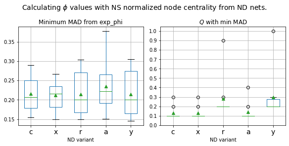

```python
fig, axes = plt.subplots(1, 2, figsize=(8, 4), constrained_layout=True)
plt.suptitle("Calculating $\phi$ values with NS normalized node centrality from ND nets.",
             fontsize=14)

ax0 = axes[0]
cent_minmad_df.boxplot(ax = ax0, showmeans=True)
ax0.set_title('Minimum MAD from exp_phi')
ax0.set_xticklabels(NDVs, fontsize=14); ax0.set_xlabel('ND variant')
# ax0.set_yticks(np.arange(0.2, 0.55, 0.05))

ax1 = axes[1]
cent_minQ_df.boxplot(ax = ax1, showmeans=True)
ax1.set_title('$Q$ with min MAD');
ax1.set_xticklabels(NDVs, fontsize=14); ax1.set_xlabel('ND variant')
_ = ax1.set_yticks(np.arange(0, 1.1, 0.1))
```

```python
# MAD between min_Qs (Q where MAD from exp_phi is minimum) and peak Qs for cxray NDVs
np.mean(np.abs(cent_minQ_df.values - peak_Qs), axis=0)
```

```
array([0.13, 0.12, 0.09, 0.13, 0.15])
```

```python
print("MAD between experimental and calculated phi-values")
cent_MADstats_df
```

```
MAD between experimental and calculated phi-values
```

| MAD_stats | c | x | r | a | y |
| --- | --- | --- | --- | --- | --- |
| sample_avg | 0.2160 | 0.2115 | 0.2144 | 0.2352 | 0.2149 |
| sample_stdev | 0.0476 | 0.0380 | 0.0594 | 0.0676 | 0.0637 |
| range | 0.1350 | 0.1170 | 0.1540 | 0.2260 | 0.1590 |
| gMOE | 0.0295 | 0.0235 | 0.0368 | 0.0419 | 0.0395 |
| 95meanCI_gleft | 0.1865 | 0.1880 | 0.1776 | 0.1933 | 0.1754 |
| 95meanCI_gright | 0.2455 | 0.2350 | 0.2512 | 0.2771 | 0.2544 |
| bMOE | 0.0280 | 0.0220 | 0.0349 | 0.0398 | 0.0369 |
| 95meanCI_bleft | 0.1890 | 0.1893 | 0.1815 | 0.1980 | 0.1786 |
| 95meanCI_bright | 0.2449 | 0.2334 | 0.2513 | 0.2775 | 0.2524 |

```python
print("Q with minimum MAD between experimental and calculated phi-values")
cent_minQstats_df
```

```
Q with minimum MAD between experimental and calculated phi-values
```

| minQ_stats | c | x | r | a | y |
| --- | --- | --- | --- | --- | --- |
| sample_avg | 0.1300 | 0.1300 | 0.2800 | 0.1400 | 0.3000 |
| sample_stdev | 0.0675 | 0.0675 | 0.2201 | 0.0966 | 0.2494 |
| range | 0.2000 | 0.2000 | 0.7000 | 0.3000 | 0.8000 |
| gMOE | 0.0418 | 0.0418 | 0.1364 | 0.0599 | 0.1546 |
| 95meanCI_gleft | 0.0882 | 0.0882 | 0.1436 | 0.0801 | 0.1454 |
| 95meanCI_gright | 0.1718 | 0.1718 | 0.4164 | 0.1999 | 0.4546 |
| bMOE | 0.0400 | 0.0350 | 0.1100 | 0.0500 | 0.1300 |
| 95meanCI_bleft | 0.1000 | 0.1000 | 0.2000 | 0.1000 | 0.2000 |
| 95meanCI_bright | 0.1800 | 0.1700 | 0.4200 | 0.2000 | 0.4600 |

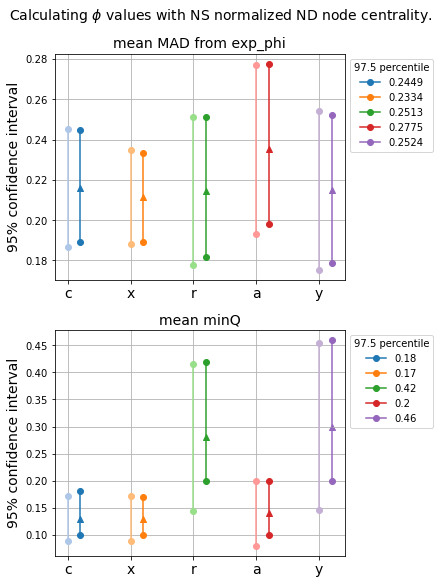

```python
plt = plot_CIs(cent_MADstats_df, cent_minQstats_df)
_ = plt.suptitle("Calculating $\phi$ values with NS normalized ND node centrality.",
                 fontsize=14)
```

```python
ndc_cent = cent_minmad_df['c'].values
ndx_cent = cent_minmad_df['x'].values
nda_cent = cent_minmad_df['a'].values
ndr_cent = cent_minmad_df['r'].values
ndy_cent = cent_minmad_df['y'].values
```

```python
print("c a")
print(ttest_rel(ndc_cent, nda_cent))
print(tts(ndc_cent.mean(), ndc_cent.std(ddof=1), 10,
    nda_cent.mean(), nda_cent.std(ddof=1), 10, equal_var=False))
print("\nx a")
print(ttest_rel(ndx_cent, nda_cent))
print(tts(ndx_cent.mean(), ndx_cent.std(ddof=1), 10,
    nda_cent.mean(), nda_cent.std(ddof=1), 10, equal_var=False))
print("\nr a")
print(ttest_rel(ndr_cent, nda_cent))
print(tts(ndr_cent.mean(), ndr_cent.std(ddof=1), 10,
    nda_cent.mean(), nda_cent.std(ddof=1), 10, equal_var=False))
print("\ny a")
print(ttest_rel(ndy_cent, nda_cent))
print(tts(ndy_cent.mean(), ndy_cent.std(ddof=1), 10,
    nda_cent.mean(), nda_cent.std(ddof=1), 10, equal_var=False))
```

```
c a
Ttest_relResult(statistic=-2.1998838344328835, pvalue=0.055351057363337036)
Ttest_indResult(statistic=-0.7341208082163616, pvalue=0.47339483909234537)

x a
Ttest_relResult(statistic=-1.645582049961906, pvalue=0.13425842442991975)
Ttest_indResult(statistic=-0.9663136086020867, pvalue=0.35010731334375245)

r a
Ttest_relResult(statistic=-2.825410134954505, pvalue=0.019870724386820936)
Ttest_indResult(statistic=-0.7308675811574417, pvalue=0.4744235544825969)

y a
Ttest_relResult(statistic=-2.476735503154165, pvalue=0.035179359273354756)
Ttest_indResult(statistic=-0.6911334993886235, pvalue=0.4983310110150768)
```

```python
minMad_c = cent_minmad_df['c'].values
minMad_a = cent_minmad_df['a'].values
print('minMad c', minMad_c)
print('minMad a', minMad_a)
minQ_c = cent_minQ_df['c'].values
minQ_a = cent_minQ_df['a'].values
print('minQ c', minQ_c)
print('minQ a', minQ_a)
```

```
minMad c [0.186 0.29  0.221 0.221 0.155 0.193 0.26  0.177 0.283 0.174]
minMad a [0.187 0.377 0.232 0.236 0.175 0.211 0.276 0.203 0.304 0.151]
minQ c [0.2 0.3 0.1 0.1 0.1 0.1 0.1 0.1 0.1 0.1]
minQ a [0.2 0.4 0.1 0.1 0.1 0.1 0.1 0.1 0.1 0.1]
```

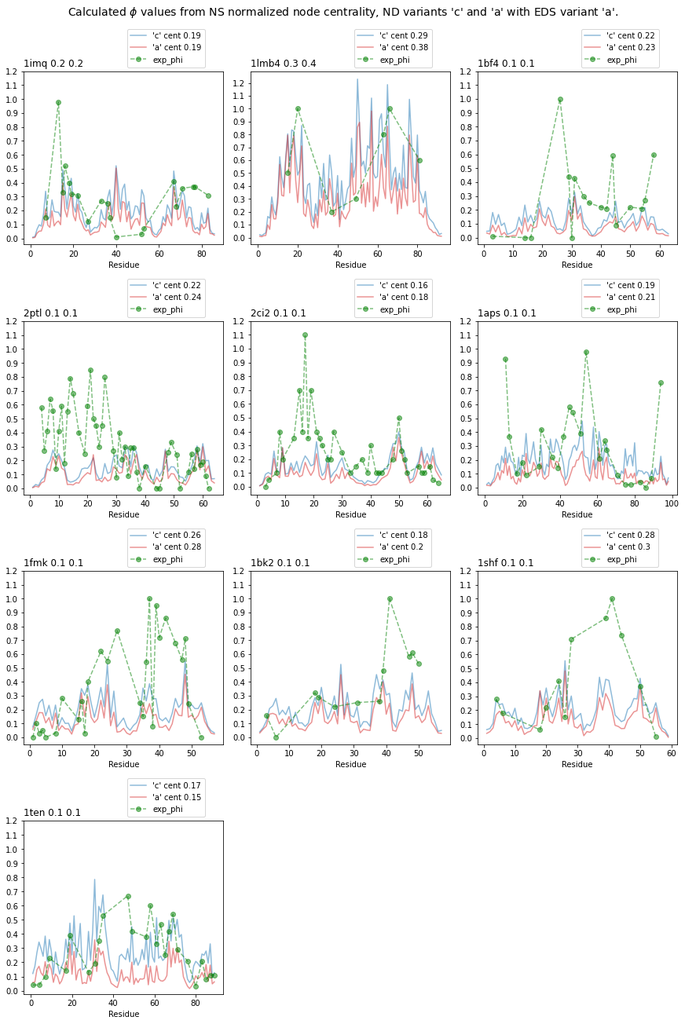

```python
fig, axes = plt.subplots(4, 3, figsize=(12, 18), constrained_layout=True)
plt.suptitle("Calculated $\phi$ values from NS normalized node centrality, \
ND variants 'c' and 'a' with EDS variant 'a'.", fontsize=14)
plt.delaxes(axes[3, 1])
plt.delaxes(axes[3, 2])
dirn = os.path.join(dirname, "edv_a") # ND data

for i, pid in enumerate(PIDs):
    r = i//3; c = i%3; ax = axes[r][c]
    fn0 = os.path.join(dirname, pid + "_nodestats.out")
    df0 = pd.read_table(fn0, sep="\s+") # nid exp_phi deg0 cent0
    N = len(df0); m = N*N-N
    fn1 = os.path.join(dirn, pid + "_c_nodestats.out")
    df1 = pd.read_table(fn1, sep="\s+")
    q_c = minQ_c[i]
    dq = df1.query("Q == @q_c")                           # 1lmb4 > 1.0?
    dq = dq.assign(cent_avg_norm2 = dq.cent_avg.values/m) # node centality is pre-averaged!
    dq = dq.assign(exp_phi = df0.exp_phi.values)
    de = dq.query("exp_phi > -1")
    mad_c = np.round(np.mean(np.abs(de.cent_avg_norm2.values - de.exp_phi.values)), 2)
    ax.plot(dq.nid.values+1, dq.cent_avg_norm2.values, color="tab:blue", alpha=0.5,
            label="'c' cent " + str(mad_c))

    fn1 = os.path.join(dirn, pid + "_a_nodestats.out")
    df1 = pd.read_table(fn1, sep="\s+")
    q_a = minQ_a[i]
    dq = df1.query("Q == @q_a")
    dq = dq.assign(cent_avg_norm2 = dq.cent_avg.values/m)
    dq = dq.assign(exp_phi = df0.exp_phi.values)
    de = dq.query("exp_phi > -1")
    mad_a = np.round(np.mean(np.abs(de.cent_avg_norm2.values - de.exp_phi.values)), 2)
    ax.plot(dq.nid.values+1, dq.cent_avg_norm2.values, color="tab:red", alpha=0.5,
            label="'a' cent " + str(mad_a))

    ax.plot(de.nid.values+1, de.exp_phi.values, "o--g", alpha=0.5, label='exp_phi')
    ax.set_title(pid + " " + str(q_c) + " " + str(q_a), loc='left')
    ax.set_xlabel('Residue'); ax.set_yticks(np.arange(0, 1.3, 0.1))
    ax.legend(loc="lower left", bbox_to_anchor=(0.5, 1.0))
    # ax.grid()
# ofn = os.path.join(dirname, "ND_centphi_ca_" + edv + ".png")
# plt.savefig(ofn)
```

- Figure above: Calculated phi-values as normalized node centrality (*cent*) of 'c' and 'a' ND generated PRNs at the $Q$ where the mean absolute difference (MAD) between experimental phi-values and *cent* is minimum. The numbers in the title of each subplot is this $Q$ for 'c' and 'a' respectively. The numbers in the legend is the MAD associated with these $Q$ values. ND node centrality for a $Q$ is the average over 100 independent ND generated PRNs at the $Q$.

### Node degree

```
1imq [0.143 0.165 0.174 0.158 0.155] [0.2 0.2 0.1 0.2 0.1]
1lmb4 [0.241 0.228 0.243 0.247 0.312] [0.3 0.3 0.2 0.3 0.2]
1bf4 [0.181 0.192 0.191 0.191 0.205] [0.1 0.1 0.1 0.1 0.1]
2ptl [0.205 0.203 0.199 0.212 0.183] [0.2 0.2 0.1 0.2 0.1]
2ci2 [0.132 0.15  0.148 0.141 0.177] [0.1 0.1 0.1 0.1 0.1]
1aps [0.219 0.231 0.22  0.209 0.215] [0.1 0.1 0.1 0.1 0.1]
1fmk [0.265 0.262 0.285 0.266 0.293] [0.2 0.2 0.1 0.1 0.1]
1bk2 [0.223 0.237 0.211 0.206 0.197] [0.1 0.1 0.1 0.1 0.1]
1shf [0.263 0.217 0.268 0.282 0.275] [0.2 0.2 0.1 0.1 0.1]
1ten [0.149 0.152 0.163 0.155 0.16 ] [0.1 0.1 0.1 0.1 0.1]
```

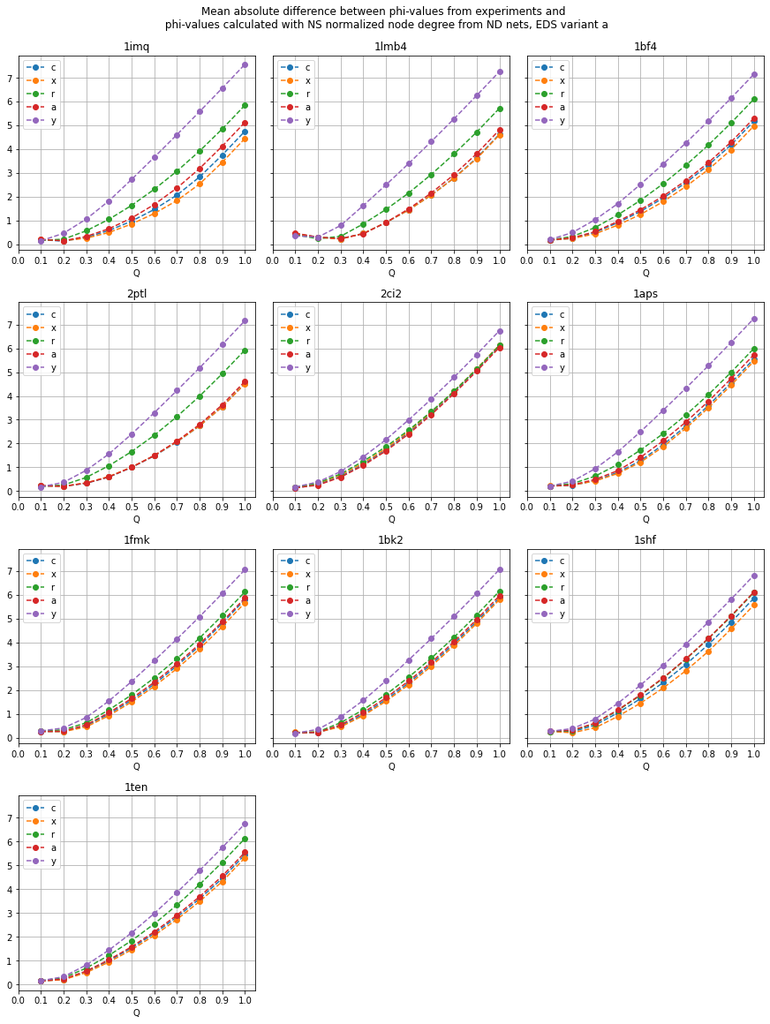

```python
# compare mads of ND variants
fig, axes = plt.subplots(4, 3, figsize=(12, 16), constrained_layout=True, sharey=True)
plt.suptitle("Mean absolute difference between phi-values from experiments and \n \
phi-values calculated with NS normalized node degree from ND nets, EDS variant " + edv)
plt.delaxes(axes[3][1])
plt.delaxes(axes[3][2])

min_mads, min_Qs = [], []
for i, pid in enumerate(PIDs):
    r = i//3; c = i%3; ax = axes[r][c]
    res = []
    for i, ndv in enumerate(NDVs):
        dp = cxray_dfs[i].query("pid == @pid")
        mad = dp.mad_deg_avg2.values
        ax.plot(Qs, mad, 'o--', label=ndv)
        res.append(mad)
    ax.set_title(pid)
    ax.set_xlabel('Q'); ax.set_xticks(np.arange(0, 1.1, 0.1))
    ax.legend(); ax.grid()
    min_mad = np.round(np.min(res, axis=1), 3) # row-wise per ND variant, over Qs for a pid
    min_q = (np.round(np.argmin(res, axis=1), 3) + 1)/10
    min_mads.append(min_mad)
    min_Qs.append(min_q)
    print(pid, min_mad, min_q)

# ofn = os.path.join(dirname, "ND_degphi_" + edv + ".png")
# plt.savefig(ofn)
```

```python
# can skip if file already exists
deg_minmad_df = pd.DataFrame(min_mads)
deg_minmad_df.columns = NDVs
deg_minmad_df = deg_minmad_df.assign(pid=PIDs).set_index('pid')
ofn = os.path.join(dirname, "ND_degphi_minmad_" + edv + ".out")
deg_minmad_df.to_csv(ofn, sep=' ')

deg_MADstats_df = pd.DataFrame({ "MAD_stats": ["sample_avg", "sample_stdev", "range", \
                                  "gMOE", "95meanCI_gleft", "95meanCI_gright",
                                  "bMOE", "95meanCI_bleft", "95meanCI_bright",],
                "c": summary_stats(deg_minmad_df['c'].values),
                "x": summary_stats(deg_minmad_df['x'].values),
                "r": summary_stats(deg_minmad_df['r'].values),
                "a": summary_stats(deg_minmad_df['a'].values),
                "y": summary_stats(deg_minmad_df['y'].values) })
deg_MADstats_df = deg_MADstats_df.set_index("MAD_stats")

# ofn = os.path.join(dirname, "ND_deg_MADstats_" + edv + ".out")
# deg_MADstats_df.to_csv(ofn, sep=' ')
```

```python
# can skip if file already exists
deg_minQ_df = pd.DataFrame(min_Qs)
deg_minQ_df.columns = NDVs
deg_minQ_df = deg_minQ_df.assign(pid=PIDs).set_index('pid')
ofn = os.path.join(dirname, "ND_degphi_minQ_" + edv + ".out")
deg_minQ_df.to_csv(ofn, sep=' ')

deg_minQstats_df = pd.DataFrame({ "minQ_stats": ["sample_avg", "sample_stdev", "range", \
                                "gMOE", "95meanCI_gleft", "95meanCI_gright",
                                "bMOE", "95meanCI_bleft", "95meanCI_bright"],
                "c": summary_stats(deg_minQ_df['c'].values),
                "x": summary_stats(deg_minQ_df['x'].values),
                "r": summary_stats(deg_minQ_df['r'].values),
                "a": summary_stats(deg_minQ_df['a'].values),
                "y": summary_stats(deg_minQ_df['y'].values)})
deg_minQstats_df = deg_minQstats_df.set_index("minQ_stats")

# ofn = os.path.join(dirname, "ND_deg_minQstats_" + edv + ".out")
# deg_minQstats_df.to_csv(ofn, sep=' ')
```

```python
# fn = os.path.join(dirname, "ND_degphi_minmad_" + edv + ".out")
# deg_minmad_df = pd.read_table(fn, sep=' ').set_index('pid')
print(deg_minmad_df.describe())
deg_minmad_df
```

```
               c          x          r         a          y
count  10.000000  10.000000  10.000000  10.00000  10.000000
mean    0.202100   0.203700   0.210200   0.20670   0.217200
std     0.048968   0.038315   0.044733   0.04767   0.056334
min     0.132000   0.150000   0.148000   0.14100   0.155000
25%     0.157000   0.171750   0.178250   0.16625   0.178500
50%     0.212000   0.210000   0.205000   0.20750   0.201000
75%     0.236500   0.230250   0.237250   0.23825   0.260000
max     0.265000   0.262000   0.285000   0.28200   0.312000
```

| pid | c | x | r | a | y |
| --- | --- | --- | --- | --- | --- |
| 1imq | 0.143 | 0.165 | 0.174 | 0.158 | 0.155 |
| 1lmb4 | 0.241 | 0.228 | 0.243 | 0.247 | 0.312 |
| 1bf4 | 0.181 | 0.192 | 0.191 | 0.191 | 0.205 |
| 2ptl | 0.205 | 0.203 | 0.199 | 0.212 | 0.183 |
| 2ci2 | 0.132 | 0.150 | 0.148 | 0.141 | 0.177 |
| 1aps | 0.219 | 0.231 | 0.220 | 0.209 | 0.215 |
| 1fmk | 0.265 | 0.262 | 0.285 | 0.266 | 0.293 |
| 1bk2 | 0.223 | 0.237 | 0.211 | 0.206 | 0.197 |
| 1shf | 0.263 | 0.217 | 0.268 | 0.282 | 0.275 |
| 1ten | 0.149 | 0.152 | 0.163 | 0.155 | 0.160 |

```python
# fn = os.path.join(dirname, "ND_degphi_minQ_" + edv + ".out")
# deg_minQ_df = pd.read_table(fn, sep=' ').set_index('pid')
print(deg_minQ_df.describe())
deg_minQ_df
```

```
               c          x          r          a          y
count  10.000000  10.000000  10.000000  10.000000  10.000000
mean    0.160000   0.160000   0.110000   0.140000   0.110000
std     0.069921   0.069921   0.031623   0.069921   0.031623
min     0.100000   0.100000   0.100000   0.100000   0.100000
25%     0.100000   0.100000   0.100000   0.100000   0.100000
50%     0.150000   0.150000   0.100000   0.100000   0.100000
75%     0.200000   0.200000   0.100000   0.175000   0.100000
max     0.300000   0.300000   0.200000   0.300000   0.200000
```

| pid | c | x | r | a | y |
| --- | --- | --- | --- | --- | --- |
| 1imq | 0.2 | 0.2 | 0.1 | 0.2 | 0.1 |
| 1lmb4 | 0.3 | 0.3 | 0.2 | 0.3 | 0.2 |
| 1bf4 | 0.1 | 0.1 | 0.1 | 0.1 | 0.1 |
| 2ptl | 0.2 | 0.2 | 0.1 | 0.2 | 0.1 |
| 2ci2 | 0.1 | 0.1 | 0.1 | 0.1 | 0.1 |
| 1aps | 0.1 | 0.1 | 0.1 | 0.1 | 0.1 |
| 1fmk | 0.2 | 0.2 | 0.1 | 0.1 | 0.1 |
| 1bk2 | 0.1 | 0.1 | 0.1 | 0.1 | 0.1 |
| 1shf | 0.2 | 0.2 | 0.1 | 0.1 | 0.1 |
| 1ten | 0.1 | 0.1 | 0.1 | 0.1 | 0.1 |

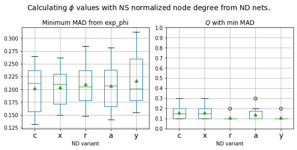

```python
fig, axes = plt.subplots(1, 2, figsize=(8, 4), constrained_layout=True)
plt.suptitle("Calculating $\phi$ values with NS normalized node degree from ND nets.",
             fontsize=14)

ax0 = axes[0]
deg_minmad_df.boxplot(ax = ax0, showmeans=True)
ax0.set_title('Minimum MAD from exp_phi')
ax0.set_xticklabels(NDVs, fontsize=14); ax0.set_xlabel('ND variant')
# ax0.set_yticks(np.arange(0.2, 0.55, 0.05))

ax1 = axes[1]
deg_minQ_df.boxplot(ax = ax1, showmeans=True)
ax1.set_title('$Q$ with min MAD');
ax1.set_xticklabels(NDVs, fontsize=14); ax1.set_xlabel('ND variant')
_ = ax1.set_yticks(np.arange(0, 1.1, 0.1))
```

```python
# MAD between min_Qs (Q where MAD from exp_phi is minimum) and peak Qs for cxray NDVs
np.mean(np.abs(deg_minQ_df.values - peak_Qs), axis=0)
```

```
array([0.1 , 0.09, 0.08, 0.11, 0.06])
```

```python
print("MAD between experimental and calculated phi-values")
deg_MADstats_df
```

```
MAD between experimental and calculated phi-values
```

| MAD_stats | c | x | r | a | y |
| --- | --- | --- | --- | --- | --- |
| sample_avg | 0.2021 | 0.2037 | 0.2102 | 0.2067 | 0.2172 |
| sample_stdev | 0.0490 | 0.0383 | 0.0447 | 0.0477 | 0.0563 |
| range | 0.1330 | 0.1120 | 0.1370 | 0.1410 | 0.1570 |
| gMOE | 0.0304 | 0.0237 | 0.0277 | 0.0295 | 0.0349 |
| 95meanCI_gleft | 0.1717 | 0.1800 | 0.1825 | 0.1772 | 0.1823 |
| 95meanCI_gright | 0.2325 | 0.2274 | 0.2379 | 0.2362 | 0.2521 |
| bMOE | 0.0290 | 0.0220 | 0.0260 | 0.0280 | 0.0331 |
| 95meanCI_bleft | 0.1727 | 0.1819 | 0.1851 | 0.1787 | 0.1857 |
| 95meanCI_bright | 0.2307 | 0.2260 | 0.2370 | 0.2346 | 0.2520 |

```python
print("Q with minimum MAD between experimental and calculated phi-values")
deg_minQstats_df
```

```
Q with minimum MAD between experimental and calculated phi-values
```

| minQ_stats | c | x | r | a | y |
| --- | --- | --- | --- | --- | --- |
| sample_avg | 0.1600 | 0.1600 | 0.1100 | 0.1400 | 0.1100 |
| sample_stdev | 0.0699 | 0.0699 | 0.0316 | 0.0699 | 0.0316 |
| range | 0.2000 | 0.2000 | 0.1000 | 0.2000 | 0.1000 |
| gMOE | 0.0433 | 0.0433 | 0.0196 | 0.0433 | 0.0196 |
| 95meanCI_gleft | 0.1167 | 0.1167 | 0.0904 | 0.0967 | 0.0904 |
| 95meanCI_gright | 0.2033 | 0.2033 | 0.1296 | 0.1833 | 0.1296 |
| bMOE | 0.0400 | 0.0400 | 0.0150 | 0.0400 | 0.0150 |
| 95meanCI_bleft | 0.1200 | 0.1200 | 0.1000 | 0.1000 | 0.1000 |
| 95meanCI_bright | 0.2000 | 0.2000 | 0.1300 | 0.1800 | 0.1300 |

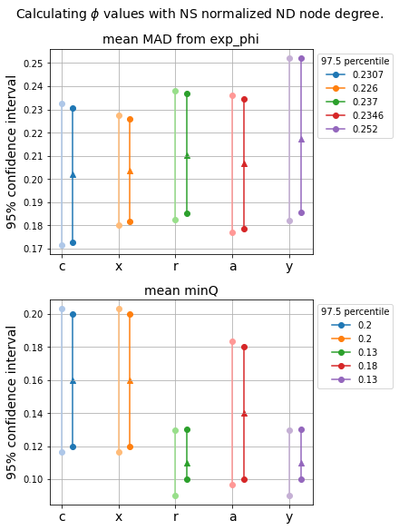

```python
plt = plot_CIs(deg_MADstats_df, deg_minQstats_df)
_ = plt.suptitle("Calculating $\phi$ values with NS normalized ND node degree.",
                 fontsize=14)
```

```python
minMad_a = deg_minmad_df['a'].values
print('minMad a', minMad_a)
minQ_a = deg_minQ_df['a'].values
print('minQ a', minQ_a)
```

```
minMad a [0.158 0.247 0.191 0.212 0.141 0.209 0.266 0.206 0.282 0.155]
minQ a [0.2 0.3 0.1 0.2 0.1 0.1 0.1 0.1 0.1 0.1]
```

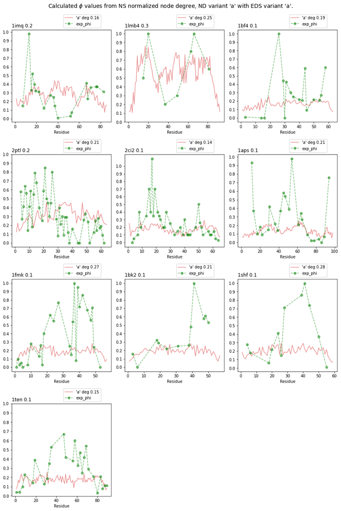

```python
fig, axes = plt.subplots(4, 3, figsize=(12, 18), constrained_layout=True)
plt.suptitle("Calculated $\phi$ values from NS normalized node degree, \
ND variant 'a' with EDS variant 'a'.", fontsize=14)
plt.delaxes(axes[3, 1])
plt.delaxes(axes[3, 2])
dirn = os.path.join(dirname, "edv_a") # ND data

for i, pid in enumerate(PIDs):
    r = i//3; c = i%3; ax = axes[r][c]
    fn0 = os.path.join(dirname, pid + "_nodestats.out")
    df0 = pd.read_table(fn0, sep="\s+") # nid exp_phi deg0 cent0

    fn1 = os.path.join(dirn, pid + "_a_nodestats.out")
    df1 = pd.read_table(fn1, sep="\s+")
    q_a = minQ_a[i]
    dq = df1.query("Q == @q_a")
    dq = dq.assign(deg_avg_norm2 = dq.deg_avg.values/df0.deg0.values)
    dq = dq.assign(exp_phi = df0.exp_phi.values)
    de = dq.query("exp_phi > -1")
    mad_a = np.round(np.mean(np.abs(de.deg_avg_norm2.values - de.exp_phi.values)), 2)
    ax.plot(dq.nid.values+1, dq.deg_avg_norm2.values, color="tab:red", alpha=0.5,
            label="'a' deg " + str(mad_a))

    ax.plot(de.nid.values+1, de.exp_phi.values, "o--g", alpha=0.5, label='exp_phi')
    ax.set_title(pid + " " + str(q_a), loc='left')
    ax.set_xlabel('Residue'); ax.set_yticks(np.arange(0, 1.1, 0.1))
    ax.legend(loc="lower left", bbox_to_anchor=(0.5, 1.0))

# ofn = os.path.join(dirname, "ND_degphi_a_" + edv + ".png")
# plt.savefig(ofn)
```

- Figure above: Calculated phi-values as normalized node degree (*deg*) of 'a' ND generated PRNs at the $Q$ where the mean absolute difference (MAD) between experimental phi-values and *deg* is minimum. The numbers in the title of each subplot is this $Q$ for 'a'. The numbers in the legend is the MAD associated with these $Q$ values. ND node degree for a $Q$ is the average over 100 independent ND generated PRNs at the $Q$.

### Summary

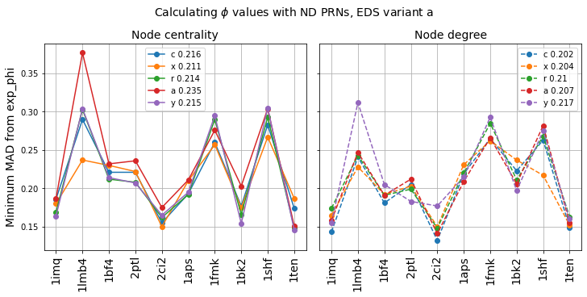

```python
fig, axes = plt.subplots(1, 2, figsize=(10, 5), constrained_layout=True, sharey=True)
plt.suptitle("Calculating $\phi$ values with ND PRNs, EDS variant " + edv, fontsize=14)

ax = axes[0]
ax.set_title("Node centrality", fontsize=14)
for ndv in NDVs:
    vals = cent_minmad_df[ndv].values
    ax.plot(PIDs, vals, 'o-', label=ndv + ' ' + str(np.round(np.mean(vals), 3)))
ax.set_xticks(PIDs); ax.set_xticklabels(PIDs, rotation=90, fontsize=14)
ax.set_ylabel("Minimum MAD from exp_phi", fontsize=14)
ax.legend(); ax.grid()

ax = axes[1]
ax.set_title("Node degree", fontsize=14)
for ndv in NDVs:
    vals = deg_minmad_df[ndv].values
    ax.plot(PIDs, vals, 'o--', label=ndv + ' ' + str(np.round(np.mean(vals), 3)))
ax.set_xticks(PIDs); ax.set_xticklabels(PIDs, rotation=90, fontsize=14)
ax.legend(); ax.grid()
# ax.set_ylabel("Minimum MAD ", fontsize=14)

# ofn = os.path.join(dirname, "ND_minMadphi_" + edv + ".png")
# plt.savefig(ofn)
```

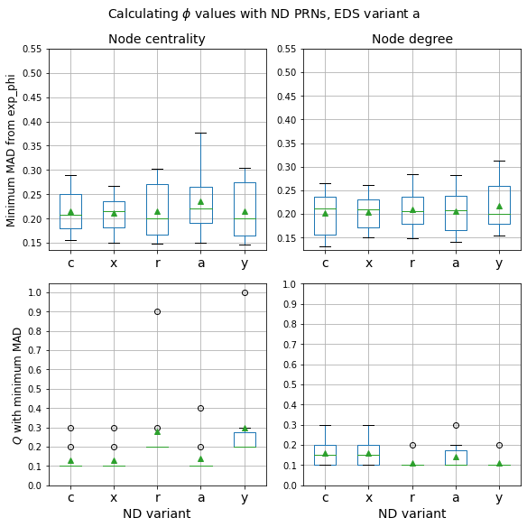

```python
fig, axes = plt.subplots(2, 2, figsize=(8, 8), constrained_layout=True)
plt.suptitle("Calculating $\phi$ values with ND PRNs, EDS variant " + edv, fontsize=14)

ax0 = axes[0][0]
cent_minmad_df.boxplot(ax = ax0, showmeans=True)
ax0.set_title('Node centrality', fontsize=14)
ax0.set_xticklabels(NDVs, fontsize=14)
ax0.set_ylabel('Minimum MAD from exp_phi', fontsize=12)
ax0.set_yticks(np.arange(0.15, 0.6, 0.05))

ax1 = axes[0][1]
deg_minmad_df.boxplot(ax = ax1, showmeans=True)
ax1.set_title('Node degree', fontsize=14)
ax1.set_xticklabels(NDVs, fontsize=14)
ax1.set_yticks(np.arange(0.15, 0.6, 0.05))

ax2 = axes[1][0]
cent_minQ_df.boxplot(ax = ax2, showmeans=True)
ax2.set_xticklabels(NDVs, fontsize=14)
ax2.set_ylabel('$Q$ with minimum MAD', fontsize=12); ax2.set_yticks(np.arange(0, 1.1, 0.1))
ax2.set_xlabel('ND variant', fontsize=14)

ax3 = axes[1][1]
deg_minQ_df.boxplot(ax = ax3, showmeans=True)
ax3.set_yticks(np.arange(0, 1.1, 0.1))
ax3.set_xticklabels(NDVs, fontsize=14)
_ = ax3.set_xlabel('ND variant', fontsize=14)

# ofn = os.path.join(dirname, "ND_phi_" + edv + ".png")
# plt.savefig(ofn)
```

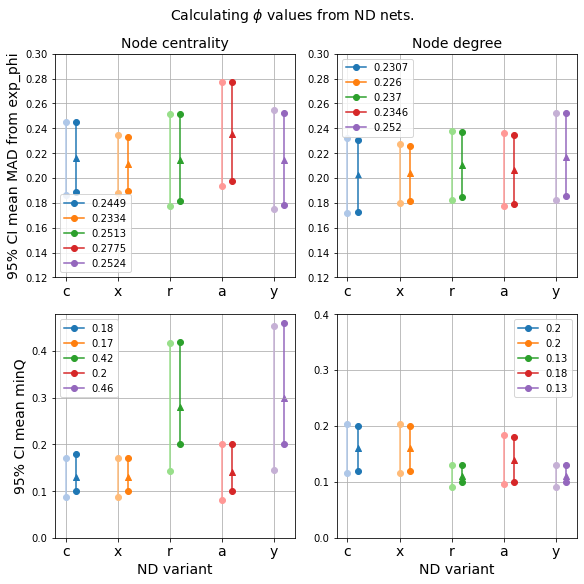

```python
methods = cent_MADstats_df.columns.values; n = len(methods)
plt_colors = plt.get_cmap("tab20")
gcolors = plt_colors(list(range(1, n*2, 2))) # odd
bcolors = plt_colors(list(range(0, n*2, 2))) # even

fig, axes = plt.subplots(2, 2, figsize=(8, 8), constrained_layout=True)
plt.suptitle("Calculating $\phi$ values from ND nets.", fontsize=14)

ax = axes[0][0]
mu = cent_MADstats_df.loc['sample_avg'].values
ga = cent_MADstats_df.loc['95meanCI_gleft'].values
gz = cent_MADstats_df.loc['95meanCI_gright'].values
ba = cent_MADstats_df.loc['95meanCI_bleft'].values
bz = cent_MADstats_df.loc['95meanCI_bright'].values
for i, p in enumerate(zip(ga, gz, ba, bz)):
    ax.plot([i, i], [p[0], p[1]], marker='o', color=gcolors[i])
    ax.plot([i+0.2, i+0.2], [p[2], p[3]], marker='o', color=bcolors[i], label=str(p[3]))
    ax.scatter(i+0.2, mu[i], marker='^')
ax.set_title("Node centrality", fontsize=14)
ax.set_yticks(np.arange(0.12, 0.32, 0.02))
ax.set_ylabel("95% CI mean MAD from exp_phi", fontsize=14)
ax.set_xticks(list(range(0, n, 1))); ax.set_xticklabels(methods, fontsize=14)
ax.legend(); ax.grid()

ax = axes[1][0]
mu = cent_minQstats_df.loc['sample_avg'].values
ga = cent_minQstats_df.loc['95meanCI_gleft'].values
gz = cent_minQstats_df.loc['95meanCI_gright'].values
ba = cent_minQstats_df.loc['95meanCI_bleft'].values
bz = cent_minQstats_df.loc['95meanCI_bright'].values
for i, p in enumerate(zip(ga, gz, ba, bz)):
    ax.plot([i, i], [p[0], p[1]], marker='o', color=gcolors[i])
    ax.plot([i+0.2, i+0.2], [p[2], p[3]], marker='o', color=bcolors[i], label=str(p[3]))
    ax.scatter(i+0.2, mu[i], marker='^')
ax.set_yticks(np.arange(0.0, 0.5, 0.1))
ax.set_ylabel("95% CI mean minQ", fontsize=14)
ax.set_xticks(list(range(0, n, 1))); ax.set_xticklabels(methods, fontsize=14)
ax.set_xlabel("ND variant", fontsize=14)
ax.legend(); ax.grid()

ax = axes[0][1]
mu = deg_MADstats_df.loc['sample_avg'].values
ga = deg_MADstats_df.loc['95meanCI_gleft'].values
gz = deg_MADstats_df.loc['95meanCI_gright'].values
ba = deg_MADstats_df.loc['95meanCI_bleft'].values
bz = deg_MADstats_df.loc['95meanCI_bright'].values
for i, p in enumerate(zip(ga, gz, ba, bz)):
    ax.plot([i, i], [p[0], p[1]], marker='o', color=gcolors[i])
    ax.plot([i+0.2, i+0.2], [p[2], p[3]], marker='o', color=bcolors[i], label=str(p[3]))
    ax.scatter(i+0.2, mu[i], marker='^')
ax.set_title("Node degree", fontsize=14)
ax.set_yticks(np.arange(0.12, 0.32, 0.02))
# ax.set_ylabel("95% confidence interval mean MAD from exp_phi", fontsize=14)
ax.set_xticks(list(range(0, n, 1))); ax.set_xticklabels(methods, fontsize=14)
ax.legend(); ax.grid()

ax = axes[1][1]
mu = deg_minQstats_df.loc['sample_avg'].values
ga = deg_minQstats_df.loc['95meanCI_gleft'].values
gz = deg_minQstats_df.loc['95meanCI_gright'].values
ba = deg_minQstats_df.loc['95meanCI_bleft'].values
bz = deg_minQstats_df.loc['95meanCI_bright'].values
for i, p in enumerate(zip(ga, gz, ba, bz)):
    ax.plot([i, i], [p[0], p[1]], marker='o', color=gcolors[i])
    ax.plot([i+0.2, i+0.2], [p[2], p[3]], marker='o', color=bcolors[i], label=str(p[3]))
    ax.scatter(i+0.2, mu[i], marker='^')
ax.set_yticks(np.arange(0.0, 0.5, 0.1))
ax.set_xticks(list(range(0, n, 1))); ax.set_xticklabels(methods, fontsize=14)
ax.set_xlabel("ND variant", fontsize=14)
ax.legend(); ax.grid()

# ofn = os.path.join(dirname, "ND_95CIstats_" + edv + ".png")
# print(ofn)
# plt.savefig(ofn)
```

### How do calculated $\phi$ values from ND PRNs fare against TSE PRNs?

```python
# MAD values computed previously
ns_deg = np.array([0.48, 0.34, 0.49, 0.35, 0.34, 0.37, 0.45, 0.35, 0.51, 0.41])
ns_cent = np.array([0.44, 0.3, 0.41, 0.29, 0.32, 0.3, 0.43, 0.35, 0.44, 0.36])
ns_locent = np.array([0.33, 0.5, 0.2, 0.19, 0.24, 0.22, 0.3, 0.15, 0.24, 0.16])

ts_deg = np.array([0.46, 0.24, 0.35, 0.29, 0.28, 0.26, 0.3, 0.28, 0.3, 0.3])
ts_deg2 = np.array([0.25, 0.21, 0.4, 0.29, 0.36, 0.35, 0.28, 0.31, 0.22, 0.32])
ts_cent = np.array([0.41, 0.34, 0.37, 0.34, 0.29, 0.26, 0.42, 0.26, 0.43, 0.4])

ndc_cent = np.array([0.394, 0.286, 0.36, 0.327, 0.26, 0.26, 0.304, 0.23, 0.391, 0.252])
nda_cent = np.array([0.274, 0.372, 0.301, 0.287, 0.251, 0.242, 0.302, 0.204, 0.399, 0.313])
nda_deg = np.array([0.33, 0.315, 0.402, 0.318, 0.271, 0.295, 0.355, 0.268, 0.444, 0.299])

ndc_cent2 = np.array([0.186, 0.29, 0.221, 0.221, 0.155, 0.193, 0.26, 0.177, 0.283, 0.174])
nda_cent2 = np.array([0.187, 0.377, 0.232, 0.236, 0.175, 0.211, 0.276, 0.203, 0.304, 0.151])
nda_deg2 = np.array([0.158, 0.247, 0.191, 0.212, 0.141, 0.209, 0.266, 0.206, 0.282, 0.155])
```

```python
# sample size is too small for CLT which 95%meanCI assumes (should actual do resampling?)
print("MAD between experimental and calculated phi-values")
df = pd.DataFrame({ "MAD_stats": ["sample_avg", "sample_stdev", "range", \
                                  "gMOE", "95meanCI_gleft", "95meanCI_gright",
                                  "bMOE", "95meanCI_bleft", "95meanCI_bright"],
                "NS_deg": summary_stats(ns_deg), "NS_cent": summary_stats(ns_cent),
                "NS_locent": summary_stats(ns_locent), "TSE_deg": summary_stats(ts_deg),
                "TSE_deg2": summary_stats(ts_deg2), "TSE_cent": summary_stats(ts_cent),
                "NDc_cent": summary_stats(ndc_cent), "NDa_cent": summary_stats(nda_cent),
                "NDa_deg": summary_stats(nda_deg),
                "NDc_cent2": summary_stats(ndc_cent2), "NDa_cent2": summary_stats(nda_cent2),
                "NDa_deg2": summary_stats(nda_deg2)})
df = df.set_index("MAD_stats")
df
```

```
MAD between experimental and calculated phi-values
```

| MAD_stats | NS_deg | NS_cent | NS_locent | TSE_deg | TSE_deg2 | TSE_cent | NDc_cent | NDa_cent | NDa_deg | NDc_cent2 | NDa_cent2 | NDa_deg2 |
| --- | --- | --- | --- | --- | --- | --- | --- | --- | --- | --- | --- | --- |
| sample_avg | 0.4090 | 0.3640 | 0.2530 | 0.3060 | 0.2990 | 0.3520 | 0.3064 | 0.2945 | 0.3297 | 0.2160 | 0.2352 | 0.2067 |
| sample_stdev | 0.0679 | 0.0613 | 0.1036 | 0.0613 | 0.0615 | 0.0648 | 0.0593 | 0.0584 | 0.0565 | 0.0476 | 0.0676 | 0.0477 |
| range | 0.1700 | 0.1500 | 0.3500 | 0.2200 | 0.1900 | 0.1700 | 0.1640 | 0.1950 | 0.1760 | 0.1350 | 0.2260 | 0.1410 |
| gMOE | 0.0421 | 0.0380 | 0.0642 | 0.0380 | 0.0381 | 0.0401 | 0.0368 | 0.0362 | 0.0350 | 0.0295 | 0.0419 | 0.0295 |
| 95meanCI_gleft | 0.3669 | 0.3260 | 0.1888 | 0.2680 | 0.2609 | 0.3119 | 0.2696 | 0.2583 | 0.2947 | 0.1865 | 0.1933 | 0.1772 |
| 95meanCI_gright | 0.4511 | 0.4020 | 0.3172 | 0.3440 | 0.3371 | 0.3921 | 0.3432 | 0.3307 | 0.3647 | 0.2455 | 0.2771 | 0.2362 |
| bMOE | 0.0400 | 0.0360 | 0.0590 | 0.0355 | 0.0360 | 0.0380 | 0.0348 | 0.0347 | 0.0333 | 0.0278 | 0.0386 | 0.0282 |
| 95meanCI_bleft | 0.3700 | 0.3280 | 0.2000 | 0.2750 | 0.2630 | 0.3140 | 0.2724 | 0.2604 | 0.2994 | 0.1891 | 0.1986 | 0.1788 |
| 95meanCI_bright | 0.4500 | 0.4000 | 0.3180 | 0.3460 | 0.3350 | 0.3900 | 0.3420 | 0.3298 | 0.3659 | 0.2447 | 0.2757 | 0.2351 |

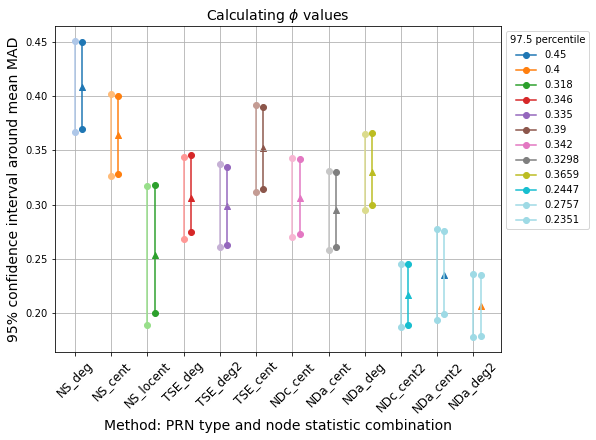

```python
plt.figure(figsize=(8, 6))

methods = df.columns.values; n = len(methods)
plt_colors = plt.get_cmap("tab20")
gcolors = plt_colors(list(range(1, n*2, 2))) # odd
bcolors = plt_colors(list(range(0, n*2, 2))) # even

mu = df.loc['sample_avg'].values
ga = df.loc['95meanCI_gleft'].values; gz = df.loc['95meanCI_gright'].values
ba = df.loc['95meanCI_bleft'].values; bz = df.loc['95meanCI_bright'].values

for i, p in enumerate(zip(ga, gz, ba, bz)):
    plt.plot([i, i], [p[0], p[1]], color=gcolors[i], marker='o')
    plt.scatter(i+0.2, mu[i], marker='^')
    plt.plot([i+0.2, i+0.2], [p[2], p[3]], color=bcolors[i], marker='o', label=str(p[3]))

plt.title("Calculating $\phi$ values", fontsize=14)
plt.xticks(list(range(0, n, 1)), methods, rotation=45, fontsize=12)
plt.xlabel("Method: PRN type and node statistic combination", fontsize=14)
plt.ylabel("95% confidence interval around mean MAD", fontsize=14)
plt.legend(title="97.5 percentile", loc="upper left", bbox_to_anchor=(1.0, 1.0)); plt.grid()

# ofn = os.path.join(dirname, "NSTSEND_95CIstats_" + edv + ".png")
# print(ofn)
# plt.savefig(ofn)
```

## End of notebook

SKLC December 2020